# The Coronavirus

The Coronavirus disease 2019 or COVID-19 is a contagious virus that has spread throughout the entire world. The virus first originated sometime in December 2019 in Wuhan, China. The virus itself is spread through the inhalation of airborne particles and droplets and because it is an infectious disease, it is highly transmissible between an infected individual and a non-infected individual.

# A Return To Normal

The benefit of mapping trends will give an idea of how successful efforts are against the Coronavirus. The purpose of this data review is to demonstrate when a “return to normal” will finally be possible.

# Background

Efficacy and duration of protection of a licensed vaccine will be a major issue [1] in the prediction of when we will reach Herd Immunity in the United States. Various aspects come into play when discussing Herd Immunity: Population Vaccinations, number of recovered infected, as well as lockdown measures currently in place to prevent new infections. Not accounting for other factors within the population and assuming efficacy is at its highest (100%), the percentage of the population that will need to be vaccinated in order to reach herd immunity will be within the range of 60% up to 90% with the assumption that the efficacy of a vaccine is lower, as low as 80%. [1]

# Exploratory Data Analysis

```r
library(RSQLite)
library(tidyverse)
library(lubridate)
library(plotly)


connection <- dbConnect(RSQLite::SQLite(), "../data/COVID.db")

x <- tbl(connection, "county") %>% collect()

dbDisconnect(connection)

vaccination_data <- x %>%
    mutate(date = date %>% ymd()) %>%
    select(date, state, county, contains("vaccination"))

MiamiDadeData <- x %>% filter(county == "Miami-Dade County")
```

## EDA Plot I - Miami Dade County

We will be reviewing the data gathered to see how the vaccinations rates are going in Miami Dade County. Specifically, we will observe the percentage of completed vaccinations.

```r
miami_dade_county_plot <- MiamiDadeData %>%
    mutate(date = date %>% ymd()) %>%
    select(date, county, contains("vaccination")) %>%
    filter(!is.na(metrics_vaccinations_completed_ratio)) %>%
    ggplot(mapping = aes(x = date, y = metrics_vaccinations_completed_ratio, color = county)) +
    geom_line() +
    geom_line(mapping = aes(y = metrics_vaccinations_initiated_ratio), color = "blue") +
    geom_hline(yintercept = 0.5) +
    lims(y = c(0, 1)) +
    theme_minimal() +
    labs(
        title = "Miami Dade County Vaccinations Completed and Initiated",
        subtitle = "Percentage of Total Population ",
        x = "Date",
        y = "PCT Vaccinations of Population"
    )

ggplotly(miami_dade_county_plot)
```

[output not shown]

## EDA Plot II - All Florida Counties

Looking at a county individually, while interesting, does not help us compare with other locations. This time we will review all Florida counties at once to see if we can see some trend or differences within a county.

```r
fl_county_vaccination_plot <- vaccination_data %>%
    filter(!is.na(metrics_vaccinations_completed_ratio)) %>%
    filter(state == "FL") %>%
    ggplot(mapping = aes(x = date, y = metrics_vaccinations_completed_ratio, color = county)) +
    geom_line() +
    geom_hline(yintercept = 0.5, linetype = "dashed", alpha = 0.5) +
    lims(y = c(0, 0.55)) +
    theme_minimal() +
    theme(legend.position = "none")+
    labs(
        title = "Florida Counties Vaccinations Completed",
        subtitle = "Percentage of Total Population of each County",
        x = "Date",
        y = "PCT Vaccinations Completed for County"
    )

ggplotly(fl_county_vaccination_plot)
```

[output not shown]

## EDA Plot III - Number of Vaccinations in Florida

```r
florida_vaccination_totals <- vaccination_data %>%
    filter(state == "FL") %>%
    group_by(date) %>%
    summarise(
        total_vaccinations_started  = sum(actuals_vaccinations_initiated),
        total_vaccinations_complete = sum(actuals_vaccinations_completed)
    ) %>%
    filter(!is.na(total_vaccinations_started)) %>%
    ggplot(mapping = aes(x = date, y = total_vaccinations_started)) +
    geom_line(color = "red") +
    geom_line(mapping = aes(y = total_vaccinations_complete), color = "blue") +
    scale_y_continuous(labels = scales::number_format(scale = 1e-6, suffix = "M")) +
    theme_bw() +
    labs(
        title = "Vaccinations Started Vs Vaccinations Completed",
        y = "Total Vaccinations (Millions)",
        x = "Date"
    )

ggplotly(florida_vaccination_totals)
```

[output not shown]

## EDA - Getting Data Transformed

We are likely to be interested in the rates of vaccinations and whether they are rising or declining. First we must transform the data.

```r
florida_vaccination_totals_df <- vaccination_data %>%
    filter(state == "FL") %>%
    group_by(date) %>%
    summarise(
        total_vaccinations_started  = sum(actuals_vaccinations_initiated),
        total_vaccinations_complete = sum(actuals_vaccinations_completed)
    ) %>%
    filter(!is.na(total_vaccinations_started)) %>%
    mutate(
        total_vacc_change_ini = total_vaccinations_complete - lag(total_vaccinations_complete, n = 1),
        total_vacc_change_com = total_vaccinations_started - lag(total_vaccinations_started, n = 1)
    )
```

```r
vaccination_rt_line_plot <- florida_vaccination_totals_df %>%
    ggplot(mapping = aes(x = date, y = total_vacc_change_com)) +
    geom_line() +
    geom_smooth() +
    scale_y_continuous(labels = scales::number_format(scale = 1e-3, suffix = "K")) +
    theme_minimal() +
    labs(
        title = "Trend of Vaccination Rates",
        x = "Date",
        y = "Number of Vaccinations"
    )

ggplotly(vaccination_rt_line_plot)
```

[output not shown]

## EDA Plot V - Vaccination Rates Continued

```r
vaccination_rt_bar_plot <- florida_vaccination_totals_df %>%
    ggplot(mapping = aes(x = date, y = total_vacc_change_com)) +
    geom_col(color = "white", fill = "black", alpha = 0.6) +
    geom_smooth(se = F, color = "red", linetype = "dashed", size = 1) +
    scale_y_continuous(labels = scales::number_format(scale = 1e-3, suffix = "K")) +
    theme_bw() +
    labs(
        title = "Bar Plot and Trendline of Vaccination Rates",
        x = "Date",
        y = "Number of Vaccinations"
    )

ggplotly(vaccination_rt_bar_plot)
```

[output not shown]

# Methodology

The topic of interest when it comes to the Coronavirus Vaccinations is when will the United States hit the threshold for Herd Immunity. This threshold is a difficult number to pinpoint as there are many factors to take into account with regard to the actual vaccinations. Several factors include: Effective Rate (the higher the effectiveness the lower the number of people required to reach herd immunity), the number of new infections, the number of former infections (population with antibodies to the virus), geographic factors such as coronavirus restrictions and population density.

## Methodology to Retrieve and Clean the Data

COVIDACTNOW.com has an API that can be called in order to retrieve COVID data numbers related to infection and vaccination rates. This API can be accessed to gain worldwide data. With regard to the United States, the API has data at a very minute granularity which we have interest in. In order to consistently pull data, I will create functions that contains the methods to perform the API call. Writing functions will result in consistency in how the data will be pulled.

I will pull this data in a script that will call the reusable functions and perform any extract, transform, load actions required for the data before storing the data. My expectation is that I will have to perform some date data clean up as the data called from the API is relatively clean.

## Methodology to Store Data - SQLite

Although the data is not large in the sense that big data implies, it is large enough that it will take time to load the data into memory. In order to facilitate this process, the cleaned data from the previous process will be written into a SQLite Database. With using outside software packages to add complexity the process, this lightweight database package will give us the functionality of a SQL database without going outside of R to perform the necessary work needed.

## Methodology for Model Creation

In order to create a model for vaccination rates I will be using regression algorithms to predict the rates. To complete this task, there will need to be prerequisite steps to summarize the data to be used with these regression methods. I expect the data will have to be summarized on a weekly or monthly basis to create some insight and actionable predictions using the dashboard.

# Results

```r
# source(file = "../scripts/functions_scripts.R")

# data <- get_state_data()
# write.csv(x = data, file = "../data/us_covid.csv")

data <- read.csv(file = "../data/us_covid.csv") %>% tibble()
data %>% glimpse()
```

```
## Rows: 25,562
## Columns: 40
## $ X                                         <int> 1, 2, 3, 4, 5, 6, 7, 8, 9, 10, 11, 12, 13, 14, 15, 16, 17, 18, 19, ~
## $ date                                      <chr> "2020-03-01", "2020-03-02", "2020-03-03", "2020-03-04", "2020-03-05~
## $ country                                   <chr> "US", "US", "US", "US", "US", "US", "US", "US", "US", "US", "US", "~
## $ state                                     <chr> "AK", "AK", "AK", "AK", "AK", "AK", "AK", "AK", "AK", "AK", "AK", "~
## $ county                                    <lgl> NA, NA, NA, NA, NA, NA, NA, NA, NA, NA, NA, NA, NA, NA, NA, NA, NA,~
## $ fips                                      <int> 2, 2, 2, 2, 2, 2, 2, 2, 2, 2, 2, 2, 2, 2, 2, 2, 2, 2, 2, 2, 2, 2, 2~
## $ lat                                       <lgl> NA, NA, NA, NA, NA, NA, NA, NA, NA, NA, NA, NA, NA, NA, NA, NA, NA,~
## $ long                                      <lgl> NA, NA, NA, NA, NA, NA, NA, NA, NA, NA, NA, NA, NA, NA, NA, NA, NA,~
## $ location_id                               <chr> "iso1:us#iso2:us-ak", "iso1:us#iso2:us-ak", "iso1:us#iso2:us-ak", "~
## $ actuals_cases                             <int> NA, NA, NA, NA, NA, NA, NA, NA, NA, NA, NA, 1, 1, 1, 1, 3, 6, 9, 12~
## $ actuals_deaths                            <int> NA, NA, NA, NA, NA, NA, NA, NA, NA, NA, NA, 0, 0, 0, 0, 0, 0, 0, 0,~
## $ actuals_positive_tests                    <int> NA, NA, NA, NA, NA, NA, NA, NA, NA, NA, 2, 2, 3, 3, 3, 8, 14, 26, 3~
## $ actuals_negative_tests                    <int> 4, 4, 6, 18, 27, 40, 50, 58, 77, 90, 139, 216, 355, 423, 537, 745, ~
```

[output cut: 27 more lines]

```r
state_data_agg <- data %>%
    filter(state %in% c("FL", "CA", "TX", "NY", "PA")) %>%
    select(date, state, contains(c("cases", "vaccinations"))) %>%
    mutate(
        date = date %>% ymd(),
        year = date %>% year(),
        month = date %>% floor_date(unit = "month"),
    ) %>%
    relocate(c("year", "month"), .after = date)

cases_vaccination_data_california <- state_data_agg %>%
    filter(state == "CA") %>%
    select(actuals_new_cases, actuals_vaccinations_initiated, actuals_vaccinations_completed) %>%
    filter_at(vars(actuals_new_cases,actuals_vaccinations_initiated, actuals_vaccinations_completed), all_vars(!is.na(.)))
```

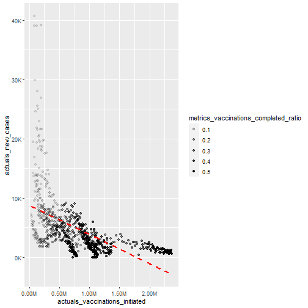

```r
cases_vaccination_data_all %>%
    ggplot(mapping = aes(x = actuals_vaccinations_initiated, y = actuals_new_cases)) +
    geom_point(mapping = aes(alpha = metrics_vaccinations_completed_ratio)) +
    scale_x_continuous(labels = scales::number_format(scale = 1e-7, suffix = "M")) +
    scale_y_continuous(labels = scales::number_format(scale = 1e-3, suffix = "K")) +
    geom_smooth(method = "lm", color = "red", linetype = "dashed", se = FALSE)
```

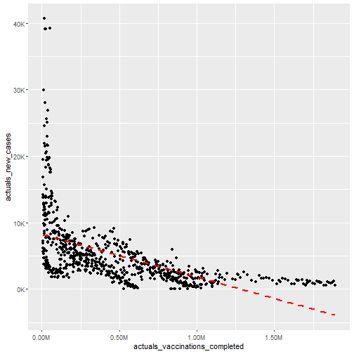

```r
cases_vaccination_data_all %>%
    ggplot(mapping = aes(x = actuals_vaccinations_completed, y = actuals_new_cases)) +
    geom_point() +
    scale_x_continuous(labels = scales::number_format(scale = 1e-7, suffix = "M")) +
    scale_y_continuous(labels = scales::number_format(scale = 1e-3, suffix = "K")) +
    geom_smooth(method = "lm", color = "red", linetype = "dashed", se = FALSE)
```

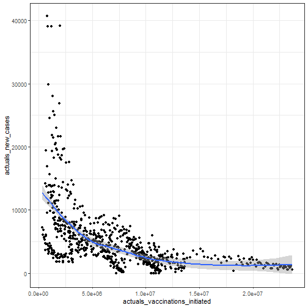

```r
cases_vaccination_data_all <- state_data_agg %>%
    select(state, actuals_new_cases, actuals_vaccinations_initiated, actuals_vaccinations_completed, metrics_vaccinations_initiated_ratio, metrics_vaccinations_completed_ratio) %>%
    filter_at(vars(actuals_new_cases,actuals_vaccinations_initiated, actuals_vaccinations_completed, metrics_vaccinations_initiated_ratio, metrics_vaccinations_completed_ratio), all_vars(!is.na(.)))


initial_plot <- cases_vaccination_data_all %>%
    ggplot(mapping = aes(x = actuals_vaccinations_initiated, y = actuals_new_cases)) +
    geom_point() +
    geom_smooth() +
    theme_bw() +
    theme(legend.position = "none")

initial_plot
```

```r
ggplotly(initial_plot)
```

[output not shown]

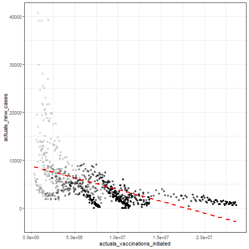

```r
lm_plot <- cases_vaccination_data_all %>%
    ggplot(mapping = aes(x = actuals_vaccinations_initiated, y = actuals_new_cases)) +
    geom_point(mapping = aes(alpha = metrics_vaccinations_completed_ratio)) +
    geom_smooth(method = "lm", color = "red", linetype = "dashed", se = FALSE) +
    theme_bw() +
    theme(legend.position = "none")

lm_plot
```

```r
ggplotly(lm_plot)
```

[output not shown]

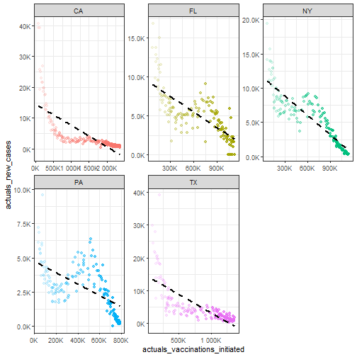

```r
cases_vaccination_data_all %>%
    ggplot(mapping = aes(
        x = actuals_vaccinations_initiated,
        y = actuals_new_cases, group = state, color = state, alpha = metrics_vaccinations_completed_ratio
    )) +
    geom_point() +
    geom_smooth(color = "black", method = "lm", se = FALSE, linetype = "dashed") +
    facet_wrap(~ state, scales = "free") +
    scale_y_continuous(labels = scales::number_format(scale = 1e-3, suffix = "K")) +
    scale_x_continuous(labels = scales::number_format(scale = 1e-4, suffix = "K")) +
    theme_bw() +
    theme(legend.position = "none")
```

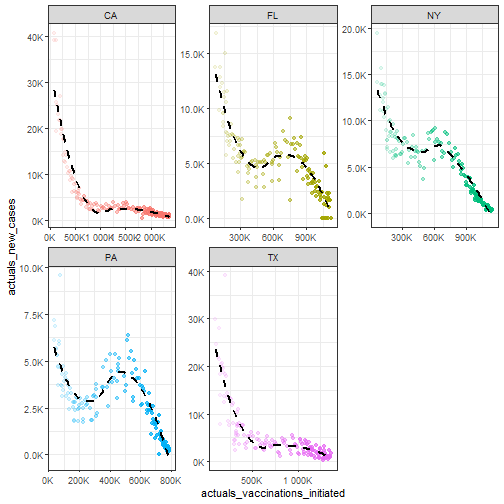

```r
cases_vaccination_data_all %>%
    ggplot(mapping = aes(
        x = actuals_vaccinations_initiated,
        y = actuals_new_cases, group = state, color = state, alpha = metrics_vaccinations_completed_ratio
    )) +
    geom_point() +
    geom_smooth(color = "black", linetype = "dashed", se = FALSE) +
    facet_wrap(~ state, scales = "free") +
    scale_y_continuous(labels = scales::number_format(scale = 1e-3, suffix = "K")) +
    scale_x_continuous(labels = scales::number_format(scale = 1e-4, suffix = "K")) +
    theme_bw() +
    theme(legend.position = "none")
```

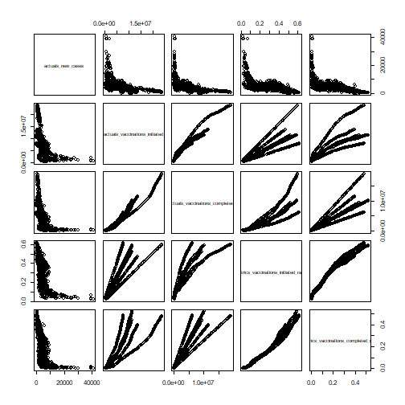

```r
vaccination_case_data <- cases_vaccination_data_all %>%
    select(-state)
pairs(vaccination_case_data)
```